# MLCourseProject

Julio Fernandez

9/8/2020

## Goals

The goal of this project is to be able to predict how a particular exercise was done by each study subject. To do this we will be using the data collected from different sensor to train a machine learning predictor that will then be apply to the data collected four our subjects of interest

```r
# Download training data
if(!file.exists("data/pml-training.csv")) {
    trainingURL <- "http://d396qusza40orc.cloudfront.net/predmachlearn/pml-training.csv"
    download.file(trainingURL, "data/pml-training.csv")
}

# Download testing data
if(!file.exists("data/pml-testing.csv")) {

    testingURL <- "https://d396qusza40orc.cloudfront.net/predmachlearn/pml-testing.csv"
    download.file(testingURL, "data/pml-testing.csv")
}

training <- read.csv("data/pml-training.csv")

# The testing file doesn't contain the classe column so it can be used for validation but not for testing
validation <- read.csv("data/pml-testing.csv")
```

## Initial data exploration and clean up

We remove variables that have NA values, columns that won’t be used as predictor variables and columns corresponding to variables with low variance

```r
## Get a summary of all the different variables available in the dataset
dim(training)
```

```
## [1] 19622   160
```

```r
#summary(training)

#head(training)
#colnames(training)

## Get the list of outcomes available for the predictor
unique(training$classe)
```

```
## [1] "A" "B" "C" "D" "E"
```

```r
# Remove columns that are not to be used
columns2remove <- c("X",
                    "user_name",
                    "raw_timestamp_part_1",
                    "Raw_timestamp_part_2",
                    "cvtd_timestamp",
                    "new_window",
                    "num_window")

columns2remove <- which(colnames(training) %in% columns2remove)


# Get list of columns with low variance
columnsWithNearZeroVar <- nearZeroVar(training)
#print(columnsWithNearZeroVar)

#Combine the two sets of columns to remove
columns2remove <- c(columns2remove, columnsWithNearZeroVar)

# Remove the columns from the training set
training.clean <- training[,-columns2remove]

# Remove columns that contain NA values
training.clean <- training.clean[ , colSums(is.na(training.clean)) == 0]

dim(training.clean)
```

```
## [1] 19622    54
```

# Classes for exercise evaluation

There are 5 different classes that can be predicted Class A corresponds to the correct execution of the exercise. The other 4 classes correspond to common mistakes

```r
#head(training.clean)
```

## Building the ML model.

### Model training

We are using Random Forrest for the prediction model. We are splitting the training set into two subset. Subset 1 will be used for model training Subset 2 will be used for model testing and calculation of Error rate

```r
# Set seed for reproducibility
set.seed(98765)

# Partition the training set into training and testing
inTrain = createDataPartition(training.clean$classe, p = 0.7)[[1]]
training.t = training.clean[ inTrain,]
testing.t = training.clean[-inTrain,]
```

```r
# Set crossvalidation
numFolds <- trainControl(method = "cv", number = 3)

## We use Random Forrest as the algorithm for prediction
classModel <- train(classe ~ .,
                    data = training.t,
                    method = "rf",
                    trControl = numFolds)
```

### Model testing

```r
# Test the model on the testing set
modelPred <- predict(classModel, testing.t)
```

Test for accuracy on the built model

```r
# Test for accuracy
confusionMatrix(factor(testing.t$classe), modelPred)$overall[1]
```

```
##  Accuracy
## 0.9916737
```

We get a very high accuracy for the model ~99%

### Model prediction

Apply the created model to the 20 new cases to predict their classe

```r
modelVal <- predict(classModel, validation)
modelVal
```

```
##  [1] B A B A A E D B A A B C B A E E A B B B
## Levels: A B C D E
```

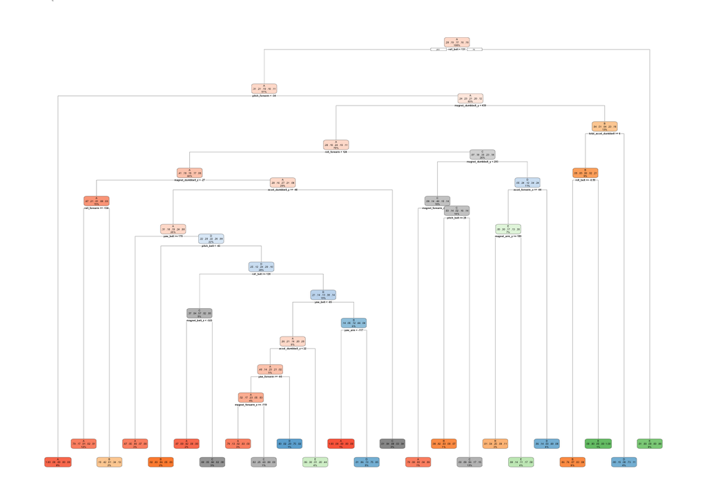

```r
treeModel <- rpart(classe ~ ., data=training.t, method="class")
rpart.plot(treeModel)
```